# Notebook

Notebook to viz FaIR output

I am currently running this notebook to viz the results from running FaIR `project` from within a sandbox. You will need to use the `fair_env` to run the notebook.

### Notebook Env: fair_env

located at `/Users/pk695/werk.M2/FACTS_dev/2401_RFF.SPs/facts_development/envs/fair_env/bin`  
activate

- Terminal `source /Users/pk695/werk.M2/FACTS_dev/2401_RFF.SPs/facts_development/envs/fair_env/bin/activate`
- Jupyter: Change the kernel in the toolbar to run the notebook.

  **If the kernel does not appear:**
  - Restart and install the new kernel using:

    ```
    ipython kernel install --user --name=fair_env
    ```

  - If that does not work, install `ipykernel`:

    ```
    pip install ipykernel
    ```

1. `rffemissions` has 3 gasses - 'C' 'CH4' 'N2' , IDX (0,1,2)
2. `emis` and `rffemfull_array` have at "C" ,"CH4" ,"N2O" ,"N2" , IDX (1,3,4,4)
   - first column is time.

Load FaIR data at the project stage

```
 <======>
rffemissions =   Size: 68MB
Dimensions:    (rff_sp: 10000, Year: 281, gas: 3)
Coordinates:
  * rff_sp     (rff_sp) int64 80kB 1 2 3 4 5 6 ... 9996 9997 9998 9999 10000
  * Year       (Year) int64 2kB 2020 2021 2022 2023 2024 ... 2297 2298 2299 2300
  * gas        (gas) object 24B 'C' 'CH4' 'N2'
Data variables:
    emissions  (gas, rff_sp, Year) float64 67MB 11.08 11.21 ... 0.1785 0.1785
Attributes:
    Description:      A compilation of 3-ghg gas emissions files from RFF con...
    Version:          v2. These emissions current as of end of Jan/early Feb ...
    Emissions Units:  C: Gt/C, CH4: Mt/CH4, N2O: Mt/N2
    Source files:     impactlab-data/gcp/integration/RFF-SP/v2/emissions/
<======>
emis shape::  (751, 40)
<======>
rffemfull_array shape:: (10, 751, 40)
<======>
```

Plot:: FaIR Input emissions

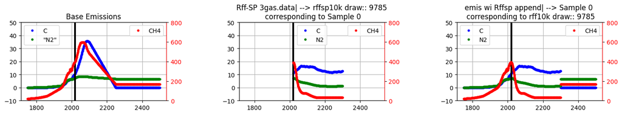

```
<Figure size 1750x237.5 with 6 Axes>
```

```
' LOOP over samples '
```

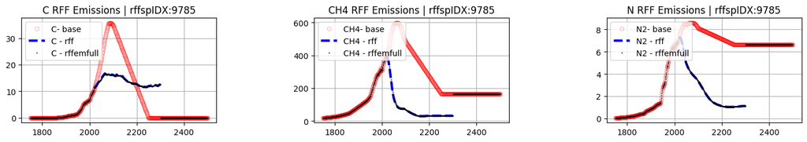

Re-calculate above. the 3-gas RFF substitution for debugging.

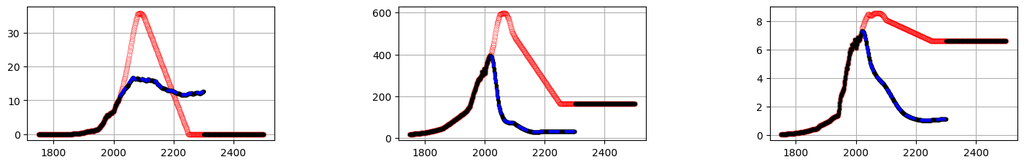

```
<Figure size 1750x237.5 with 3 Axes>
```

PLOT :: base-emis VS 3-Gas

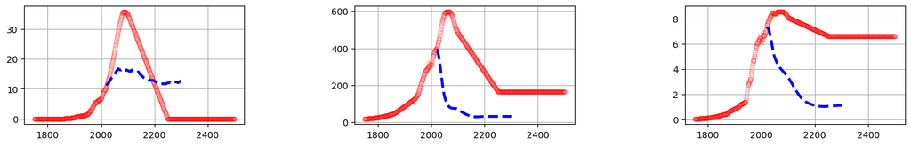

```
<Figure size 1750x237.5 with 3 Axes>
```

Viz project script result .V.S. this ipynb calc

```
sample=0, project sandbox result
```

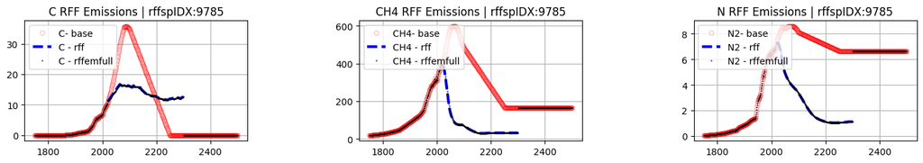

```
nbk based calculation
```

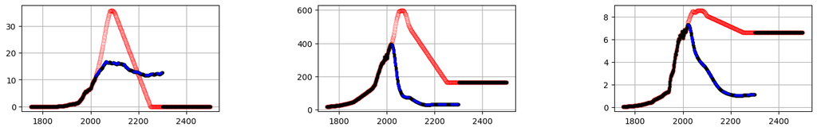

```
<Figure size 1750x237.5 with 3 Axes>
```

```
sample=1, project sandbox result
```

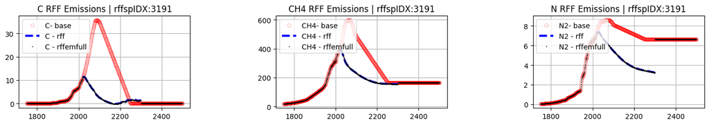

```
<Figure size 1750x237.5 with 3 Axes>
```

```
nbk based calculation
```

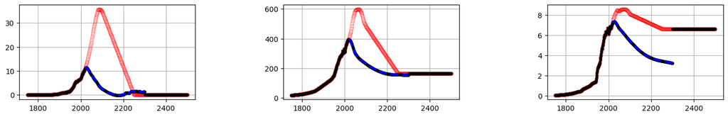

```
<Figure size 1750x237.5 with 3 Axes>
```

```
sample=2, project sandbox result
```

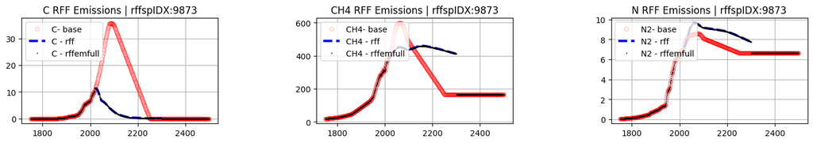

```
<Figure size 1750x237.5 with 3 Axes>
```

```
nbk based calculation
```

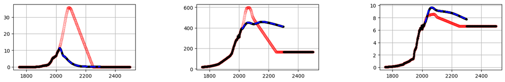

```
<Figure size 1750x237.5 with 3 Axes>
```

```
sample=3, project sandbox result
```

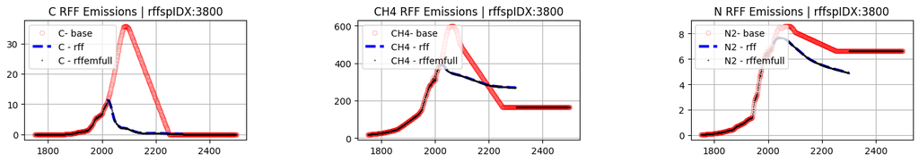

```
<Figure size 1750x237.5 with 3 Axes>
```

```
nbk based calculation
```

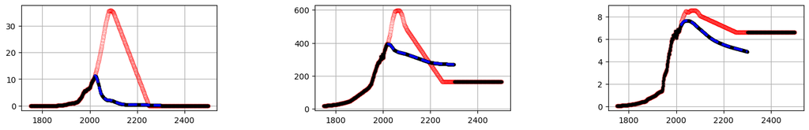

```
<Figure size 1750x237.5 with 3 Axes>
```

```
sample=4, project sandbox result
```

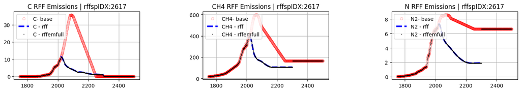

```
<Figure size 1750x237.5 with 3 Axes>
```

```
nbk based calculation
```

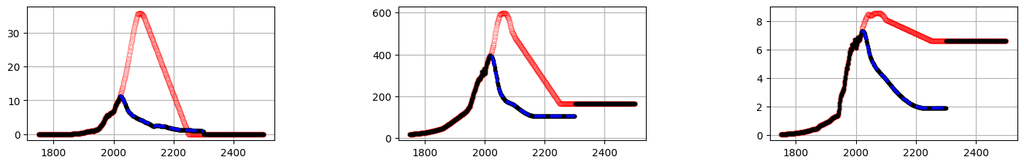

```
<Figure size 1750x237.5 with 3 Axes>
```

```
sample=5, project sandbox result
```

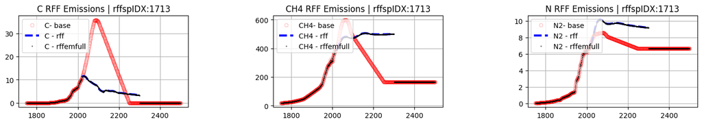

```
<Figure size 1750x237.5 with 3 Axes>
```

```
nbk based calculation
```

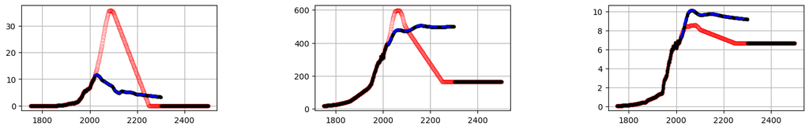

```
<Figure size 1750x237.5 with 3 Axes>
```

```
sample=6, project sandbox result
```

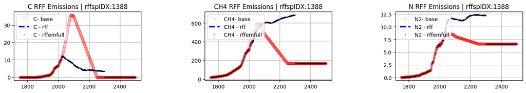

```
<Figure size 1750x237.5 with 3 Axes>
```

```
nbk based calculation
```

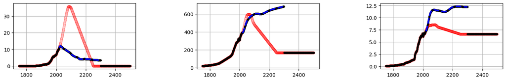

```
<Figure size 1750x237.5 with 3 Axes>
```

```
sample=7, project sandbox result
```

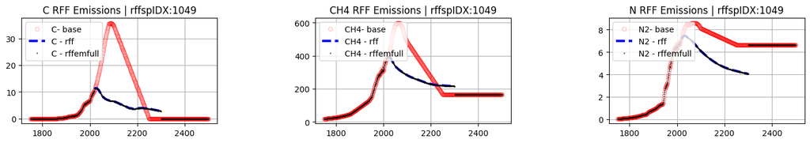

```
<Figure size 1750x237.5 with 3 Axes>
```

```
nbk based calculation
```

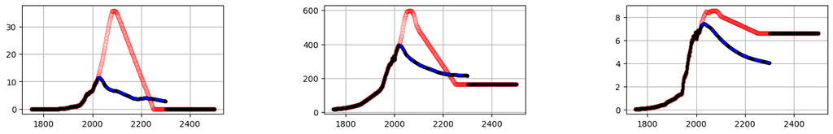

```
<Figure size 1750x237.5 with 3 Axes>
```

```
sample=8, project sandbox result
```

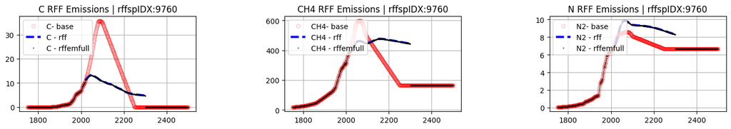

```
<Figure size 1750x237.5 with 3 Axes>
```

```
nbk based calculation
```

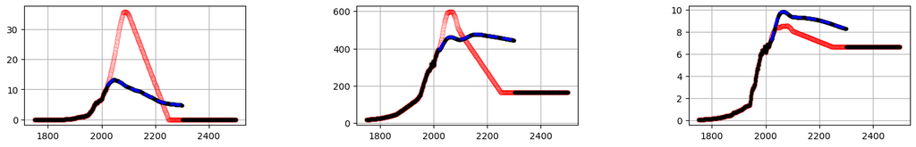

```
<Figure size 1750x237.5 with 3 Axes>
```

```
sample=9, project sandbox result
```

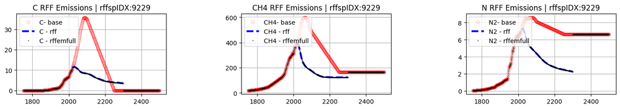

```
<Figure size 1750x237.5 with 3 Axes>
```

```
nbk based calculation
```

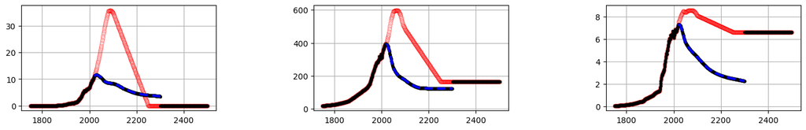

```
<Figure size 1750x237.5 with 3 Axes>
```

Cumulative Emissions

[output not shown]

Plot:: FaIR output

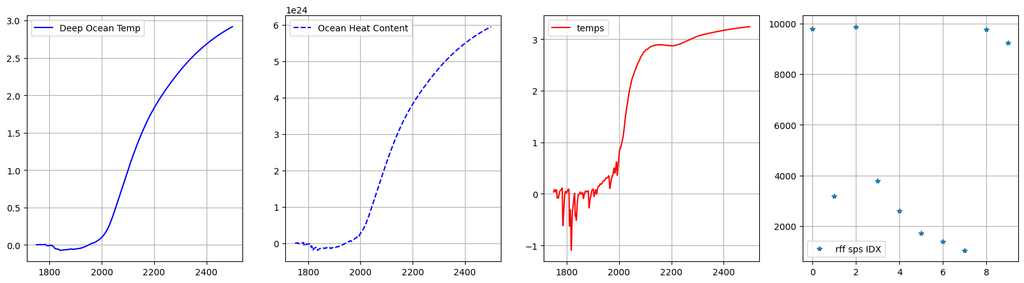

```
array([9785, 3191, 9873, 3800, 2617, 1713, 1388, 1049, 9760, 9229])
```

Check sampling randomness

Gas Species

```
| Index | Species                               | Emissions Species     |
|-------|---------------------------------------|------------------------|
| 1     | CO2|MAGICC Fossil and Industrial    | CO2_Fossil           |
| 2     | CO2|MAGICC AFOLU                    | CO2_Land             |
| 3     | CH4                                 | CH4                  |
| 4     | N2O                                 | N2O                  |
| 5     | Sulfur                              | SOx                  |
| 6     | CO                                  | CO                   |
| 7     | VOC                                 | NMVOC                |
| 8     | NOx                                 | NOx                  |
| 9     | BC                                  | BC                   |
| 10     | |OC                                 | OC                   |
| 11     | NH3                                 | NH3                  |
| 12     | CF4                                 | CF4                  |
| 13     | C2F6                                | C2F6                 |
| 14     | C6F14                               | C6F14                |
| 15     | HFC23                               | HFC23                |
| 16     | HFC32                               | HFC32                |
| 17     | HFC4310mee                          | HFC4310mee           |
| 18     | HFC125                              | HFC125               |
| 19     | HFC134a                             | HFC134a              |
| 20     | HFC143a                             | HFC143a              |
| 21     | HFC227ea                            | HFC227ea             |
| 22     | HFC245fa                            | HFC245fa             |
| 23     | SF6                                 | SF6                  |
| 24     | CFC11                               | CFC11                |
| 25     | CFC12                               | CFC12                |
| 26     | CFC113                              | CFC113               |
| 27     | CFC114                              | CFC114               |
| 28     | CFC115                              | CFC115               |
| 29     | CCl4                                | CARB_TET             |
| 30     | CH3CCl3                             | MCF                  |
| 31     | HCFC22                              | HCFC22               |
| 32     | HCFC141b                            | HCFC141b             |
| 33     | HCFC142b                            | HCFC142b             |
| 34     | Halon1211                           | Halon1211            |
| 35     | Halon1202                           | Halon1202            |
| 36     | Halon1301                           | Halon1301            |
| 37     | Halon2402                           | Halon2402            |
| 38     | CH3Br                               | CH3Br                |
| 39     | |CH3Cl                              | CH3Cl                |


**Total species count: 39**
```

##### Full list

```
| Index | Variable                             |
|-------|--------------------------------------|
| 0     | Emissions|BC |
| 1     | Emissions|CH4 |
| 2     | Emissions|CO |
| 3     | Emissions|CO2 |
| 4     | Emissions|CO2|MAGICC AFOLU |
| 5     | Emissions|CO2|MAGICC Fossil and Industrial |
| 6     | Emissions|F-Gases|HFC|HFC125 |
| 7     | Emissions|F-Gases|HFC|HFC134a |
| 8     | Emissions|F-Gases|HFC|HFC143a |
| 9     | Emissions|F-Gases|HFC|HFC227ea |
| 10     | Emissions|F-Gases|HFC|HFC23 |
| 11     | Emissions|F-Gases|HFC|HFC245fa |
| 12     | Emissions|F-Gases|HFC|HFC32 |
| 13     | Emissions|F-Gases|HFC|HFC4310mee |
| 14     | Emissions|F-Gases|PFC|C2F6 |
| 15     | Emissions|F-Gases|PFC|C6F14 |
| 16     | Emissions|F-Gases|PFC|CF4 |
| 17     | Emissions|F-Gases|SF6 |
| 18     | Emissions|Montreal Gases|CCl4 |
| 19     | Emissions|Montreal Gases|CFC|CFC11 |
| 20     | Emissions|Montreal Gases|CFC|CFC113 |
| 21     | Emissions|Montreal Gases|CFC|CFC114 |
| 22     | Emissions|Montreal Gases|CFC|CFC115 |
| 23     | Emissions|Montreal Gases|CFC|CFC12 |
| 24     | Emissions|Montreal Gases|CH3Br |
| 25     | Emissions|Montreal Gases|CH3CCl3 |
| 26     | Emissions|Montreal Gases|CH3Cl |
| 27     | Emissions|Montreal Gases|HCFC141b |
| 28     | Emissions|Montreal Gases|HCFC142b |
| 29     | Emissions|Montreal Gases|HCFC22 |
| 30     | Emissions|Montreal Gases|Halon1202 |
| 31     | Emissions|Montreal Gases|Halon1211 |
| 32     | Emissions|Montreal Gases|Halon1301 |
| 33     | Emissions|Montreal Gases|Halon2402 |
| 34     | Emissions|N2O |
| 35     | Emissions|NH3 |
| 36     | Emissions|NOx |
| 37     | Emissions|OC |
| 38     | Emissions|Sulfur |
| 39     | Emissions|VOC |
| 40     | Emissions|BC|MAGICC AFOLU |
| 41     | Emissions|BC|MAGICC AFOLU|Agricultural Waste Burning |
| 42     | Emissions|BC|MAGICC AFOLU|Agriculture |
| 43     | Emissions|BC|MAGICC AFOLU|Forest Burning |
| 44     | Emissions|BC|MAGICC AFOLU|Grassland Burning |
| 45     | Emissions|BC|MAGICC AFOLU|Peat Burning |
| 46     | Emissions|BC|MAGICC Fossil and Industrial |
| 47     | Emissions|BC|MAGICC Fossil and Industrial|Aircraft |
| 48     | Emissions|BC|MAGICC Fossil and Industrial|Energy Sector |
| 49     | Emissions|BC|MAGICC Fossil and Industrial|Industrial Sector |
| 50     | Emissions|BC|MAGICC Fossil and Industrial|International Shipping |
| 51     | Emissions|BC|MAGICC Fossil and Industrial|Residential Commercial Other |
| 52     | Emissions|BC|MAGICC Fossil and Industrial|Solvents Production and Application |
| 53     | Emissions|BC|MAGICC Fossil and Industrial|Transportation Sector |
| 54     | Emissions|BC|MAGICC Fossil and Industrial|Waste |
| 55     | Emissions|CH4|MAGICC AFOLU |
| 56     | Emissions|CH4|MAGICC AFOLU|Agricultural Waste Burning |
| 57     | Emissions|CH4|MAGICC AFOLU|Agriculture |
| 58     | Emissions|CH4|MAGICC AFOLU|Forest Burning |
| 59     | Emissions|CH4|MAGICC AFOLU|Grassland Burning |
| 60     | Emissions|CH4|MAGICC AFOLU|Peat Burning |
| 61     | Emissions|CH4|MAGICC Fossil and Industrial |
| 62     | Emissions|CH4|MAGICC Fossil and Industrial|Energy Sector |
| 63     | Emissions|CH4|MAGICC Fossil and Industrial|Industrial Sector |
| 64     | Emissions|CH4|MAGICC Fossil and Industrial|International Shipping |
| 65     | Emissions|CH4|MAGICC Fossil and Industrial|Residential Commercial Other |
| 66     | Emissions|CH4|MAGICC Fossil and Industrial|Solvents Production and Application |
| 67     | Emissions|CH4|MAGICC Fossil and Industrial|Transportation Sector |
| 68     | Emissions|CH4|MAGICC Fossil and Industrial|Waste |
| 69     | Emissions|CO2|MAGICC Fossil and Industrial|Aircraft |
| 70     | Emissions|CO2|MAGICC Fossil and Industrial|Energy Sector |
| 71     | Emissions|CO2|MAGICC Fossil and Industrial|Industrial Sector |
| 72     | Emissions|CO2|MAGICC Fossil and Industrial|International Shipping |
| 73     | Emissions|CO2|MAGICC Fossil and Industrial|Residential Commercial Other |
| 74     | Emissions|CO2|MAGICC Fossil and Industrial|Solvents Production and Application |
| 75     | Emissions|CO2|MAGICC Fossil and Industrial|Transportation Sector |
| 76     | Emissions|CO2|MAGICC Fossil and Industrial|Waste |
| 77     | Emissions|CO|MAGICC AFOLU |
| 78     | Emissions|CO|MAGICC AFOLU|Agricultural Waste Burning |
| 79     | Emissions|CO|MAGICC AFOLU|Agriculture |
| 80     | Emissions|CO|MAGICC AFOLU|Forest Burning |
| 81     | Emissions|CO|MAGICC AFOLU|Grassland Burning |
| 82     | Emissions|CO|MAGICC AFOLU|Peat Burning |
| 83     | Emissions|CO|MAGICC Fossil and Industrial |
| 84     | Emissions|CO|MAGICC Fossil and Industrial|Aircraft |
| 85     | Emissions|CO|MAGICC Fossil and Industrial|Energy Sector |
| 86     | Emissions|CO|MAGICC Fossil and Industrial|Industrial Sector |
| 87     | Emissions|CO|MAGICC Fossil and Industrial|International Shipping |
| 88     | Emissions|CO|MAGICC Fossil and Industrial|Residential Commercial Other |
| 89     | Emissions|CO|MAGICC Fossil and Industrial|Solvents Production and Application |
| 90     | Emissions|CO|MAGICC Fossil and Industrial|Transportation Sector |
| 91     | Emissions|CO|MAGICC Fossil and Industrial|Waste |
| 92     | Emissions|F-Gases|HFC|HFC152a |
| 93     | Emissions|F-Gases|HFC|HFC236fa |
| 94     | Emissions|F-Gases|HFC|HFC365mfc |
| 95     | Emissions|F-Gases|NF3 |
| 96     | Emissions|F-Gases|PFC|C3F8 |
| 97     | Emissions|F-Gases|PFC|C4F10 |
| 98     | Emissions|F-Gases|PFC|C5F12 |
| 99     | Emissions|F-Gases|PFC|C7F16 |
| 100     | Emissions|F-Gases|PFC|C8F18 |
| 101     | Emissions|F-Gases|PFC|cC4F8 |
| 102     | Emissions|F-Gases|SO2F2 |
| 103     | Emissions|Montreal Gases|CH2Cl2 |
| 104     | Emissions|Montreal Gases|CHCl3 |
| 105     | Emissions|N2O|MAGICC AFOLU |
| 106     | Emissions|N2O|MAGICC Fossil and Industrial |
| 107     | Emissions|NH3|MAGICC AFOLU |
| 108     | Emissions|NH3|MAGICC AFOLU|Agricultural Waste Burning |
| 109     | Emissions|NH3|MAGICC AFOLU|Agriculture |
| 110     | Emissions|NH3|MAGICC AFOLU|Forest Burning |
| 111     | Emissions|NH3|MAGICC AFOLU|Grassland Burning |
| 112     | Emissions|NH3|MAGICC AFOLU|Peat Burning |
| 113     | Emissions|NH3|MAGICC Fossil and Industrial |
| 114     | Emissions|NH3|MAGICC Fossil and Industrial|Aircraft |
| 115     | Emissions|NH3|MAGICC Fossil and Industrial|Energy Sector |
| 116     | Emissions|NH3|MAGICC Fossil and Industrial|Industrial Sector |
| 117     | Emissions|NH3|MAGICC Fossil and Industrial|International Shipping |
| 118     | Emissions|NH3|MAGICC Fossil and Industrial|Residential Commercial Other |
| 119     | Emissions|NH3|MAGICC Fossil and Industrial|Solvents Production and Application |
| 120     | Emissions|NH3|MAGICC Fossil and Industrial|Transportation Sector |
| 121     | Emissions|NH3|MAGICC Fossil and Industrial|Waste |
| 122     | Emissions|NOx|MAGICC AFOLU |
| 123     | Emissions|NOx|MAGICC AFOLU|Agricultural Waste Burning |
| 124     | Emissions|NOx|MAGICC AFOLU|Agriculture |
| 125     | Emissions|NOx|MAGICC AFOLU|Forest Burning |
| 126     | Emissions|NOx|MAGICC AFOLU|Grassland Burning |
| 127     | Emissions|NOx|MAGICC AFOLU|Peat Burning |
| 128     | Emissions|NOx|MAGICC Fossil and Industrial |
| 129     | Emissions|NOx|MAGICC Fossil and Industrial|Aircraft |
```